# Firearm Laws - Difference in Difference (Part 2)

Ralf Becker

## Introduction

Here we are looking at replicating aspects of this paper:

Siegel et al (2019) The Impact of State Firearm Laws on Homicide and Suicide Deaths in the USA, 1991–2016: a Panel Study, J Gen Intern Med 34(10):2021–8.

In Part 1 - Data acquisition and management, we organised the data in a new datafile saved in “US Gun_example_v3.csv”. We will continue working from that datafile and in this part we will apply the Difference in Difference methodology. This is a common methodology to evaluate the effectiveness of a policy. We will use this methodology here to evaluate whether laws aimed to regulate gun ownership (such as background check) have any measurable effect on the number of firearm deaths.

## Load packages

Let’s start by loading the packages we will use throughout this work.

```r
library(tidyverse)
library(readxl)
library(stringr)
library(ggplot2)
library(plm)          # for panel data
library(sandwich)     # for cluster robust standard errors
library(stargazer)    # for nice regression output
library(stringr)      # to extract strings
library(coefplot)     # to create coefficient plots
library(AER)          # to use lht
```

We will later apply regression analysis in order to implement the Difference-in-Difference method. Here we will use the standard regression function in R, the `lm` function, but to implement the proper inference procedure (heteroskedasticity robust standard errors) we will display the regression results with the `stargazer_hc` function. This is an amended form of the `stargazer` function. The `stargazer_hc` function can be downloaded from [here](https://raw.githubusercontent.com/datasquad/ECLR/gh-pages/Ex/stargazer_HC.R). Save it into your working directory such that you can load it using the following command:

```r
source("Stargazer_HC.R")
```

## Load Data

In the last step of Part 1 we saved all data in a well formatted datafile “US Gun_example_v3.csv”, [which you can download from here](https://raw.githubusercontent.com/datasquad/ECLR/refs/heads/gh-pages/data/US%20Gun_example_v3.csv) such that you can then load it:

```r
datadir <- "data/"  # folder in which my data are saved, adjust to your own data location

# ensure you know where you saved this file from Part 1
data3 <- read.csv(paste0(datadir,"US Gun_example_v3.csv"))

# we also load the laws codebook just in case we need to refer to it
law_data_codebook <- read_excel(paste0(datadir,"Firearmlaws codebook_0.xlsx"))
names(law_data_codebook) = make.names(names(law_data_codebook)) # This elimnates spaces in variable names
```

Let’s recall what variables are included in `data3`:

```r
names(data3)
```

```
##  [1] "X"                 "Year"              "State"
##  [4] "State_code"        "State_num_code"    "Population"
##  [7] "firearm.deaths.pc" "Region"            "pol_ubc"
## [10] "pol_vmisd"         "pol_mayissue"      "ur"
## [13] "law.officers.pc"   "vcrime.pc"         "homi.pc"
## [16] "alcc.pc"           "incarc.pc"         "prop18.24"
```

## Summary Stats and Data Exploration

Let’s calculate some firearm death statistics. The data from the CDC deliver an age adjusted rate, which is the number of deaths for every 100,000 of population in state $s$ in a particular year $t$. Let’s average that rate in each state across all years.

```r
table2 <- data3 %>% group_by(State) %>%
                          summarise(avg_fd.pc = mean(firearm.deaths.pc,na.rm = TRUE), n=n()) %>%
                          arrange(-avg_fd.pc) %>%  # sort in decreasing order of avg_aarate
                          print()
```

```
## # A tibble: 51 × 3
##    State                avg_fd.pc     n
##    <chr>                    <dbl> <int>
##  1 Louisiana                 20.2    21
##  2 Alaska                    19.9    21
##  3 Mississippi               19.7    21
##  4 Alabama                   18.5    21
##  5 District of Columbia      18.1    21
##  6 Wyoming                   17.9    21
##  7 New Mexico                17.2    21
##  8 Montana                   17.1    21
##  9 Arkansas                  17.0    21
## 10 Tennessee                 16.2    21
## # ℹ 41 more rows
```

If you are working on replicating or extending some published work you should try and see whether your data are the same as the ones used in the publication you are working on. This is best done by matching your own summary statistics to those in the paper. The Siegel et al (2019) paper does not really have any descriptive statistics, but report some data for 2016 (their Table 2). They report, for 2016, an age adjusted homicide rate of 14.2. Let’s look at our data for Louisiana in 2016:

```r
data3 %>% filter(Year == 2016, State == "Louisiana") %>%
  select(State, Year, firearm.deaths.pc, homi.pc)
```

```
##       State Year firearm.deaths.pc  homi.pc
## 1 Louisiana 2016              21.2 11.85556
```

In the table above you can see that we have a value of 21.20 (per 100,000 population) firearm deaths in Louisiana for 2016. That is not the same as the 14.2 in the paper but we wouldn’t expect this as theirs does include all homicides regardless of the method of death. The firearm deaths data, while being age adjusted, does not actually record whether a death was a suicide or homicide, but only registered the mechanism of death. Of course a death by firearm could be either a homicide or a suicide.

The homicide data we obtained from the F.B.I. website (`homi.pc`) are not age adjusted data. This may well explain the difference between the rate of 11.86 reported here and the age adjusted homicide rate of 14.2 in the paper.

In summary, we do not have exactly the same data to replicate Siegel et al’s analysis. But both variables are in a similar ballpark and are logically connected.

This means that in our subsequent analysis we can either use the age adjusted firearm deaths data (`firearm.deaths.pc`) or the non-age adjusted homicide data (`homi.pc`). We could of course also attempt to apply the age adjustment procedure, but we will not do this here. For now we will use `firearm.deaths.pc` as the main outcome variable.

Let’s look at a few time-series plots of the data. Whenever you are working with data that have a time-series dimension, plots such as these will give the reader a better understanding of the data, and are strongly recommended.

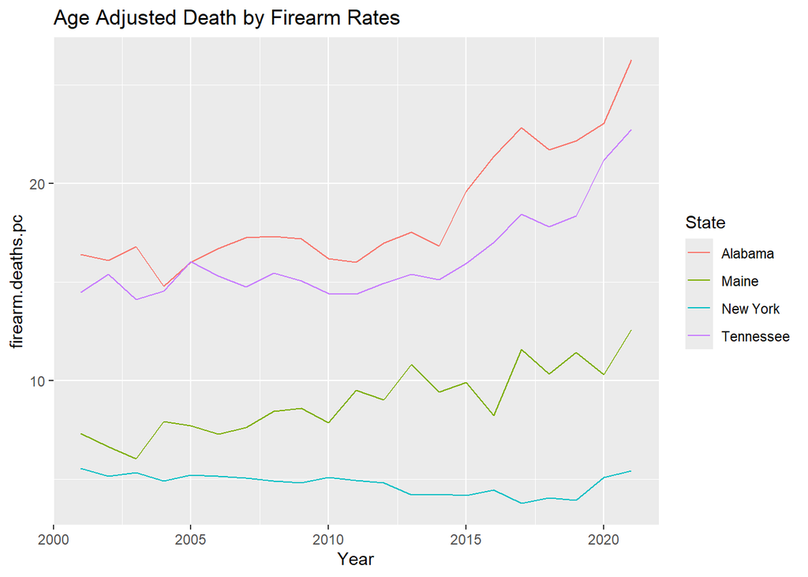

```r
plot1data <- data3 %>% filter(State %in% c("Alabama","Tennessee","Maine", "New York"))
p1 <- ggplot(plot1data, aes( x = Year, y = firearm.deaths.pc, color = State)) +
            geom_line() +
            labs(title="Age Adjusted Death by Firearm Rates")
p1
```

For three of these states, there an upward trend in the number of firearm deaths after 2015 (New York is the exception).

## Initial Diff-in-Diff

Here we expect that you have an understanding of the difference-in-difference (DiD) methodology. Certain aspects will be elaborated on below, but this walkthrough is not meant to be an initial introduction to this methodology. If you want such an introduction, then this [R-Workthrough](https://datasquad.github.io/ECLR/Ex/CardKrueger.html) of Card and Kruegers seminal paper on the effect of minimum wages is a better starting point.

In short, what is needed for a DiD analysis is a number of units (here US States) with data over a time period which starts before one or some of the states implemented some policy and extends until a few periods after that policy introduction. It is also important that some states implemented the policy and others did not.

### Policy set-up

We wish to evaluate whether various gun control policies have a causal effect. The policies considered here are (a) the universal background checks policy (`pol_ubc`), (b) policies that prevent person with recorded violent misdemeanors from owning a gun (`pol_vmisd`) and (c) the so-called may issue laws (`pol_mayissue`), which gives authorities the discretion to grant a permit to carry a concealed gun (or otherwise).

For (a) let’s remind ourselves how the policy variables are coded in the data.

```r
unique(data3$pol_ubc)
```

```
## [1]  0  1 NA
```

You can see that the `pol_ubc` variable only contains 0s and 1s. That is the same for the other policy variables `pol_vmisd` and `pol_mayissue`. Let’s calculate summary statistics for these:

```r
summary(data3[c("pol_ubc","pol_vmisd", "pol_mayissue")])
```

```
##     pol_ubc       pol_vmisd     pol_mayissue
##  Min.   :0.00   Min.   :0.00   Min.   :0.000
##  1st Qu.:0.00   1st Qu.:0.00   1st Qu.:0.000
##  Median :0.00   Median :0.00   Median :0.000
##  Mean   :0.15   Mean   :0.32   Mean   :0.245
##  3rd Qu.:0.00   3rd Qu.:1.00   3rd Qu.:0.000
##  Max.   :1.00   Max.   :1.00   Max.   :1.000
##  NA's   :71     NA's   :71     NA's   :71
```

Given this is a binary variable, the mean values give you the proportion of observations for which the value is 1. There are also missing observations. The come from missing policy information for 2021 and for the District of Columbia.

Let us also repeat a plot we already looked at in Part 1.

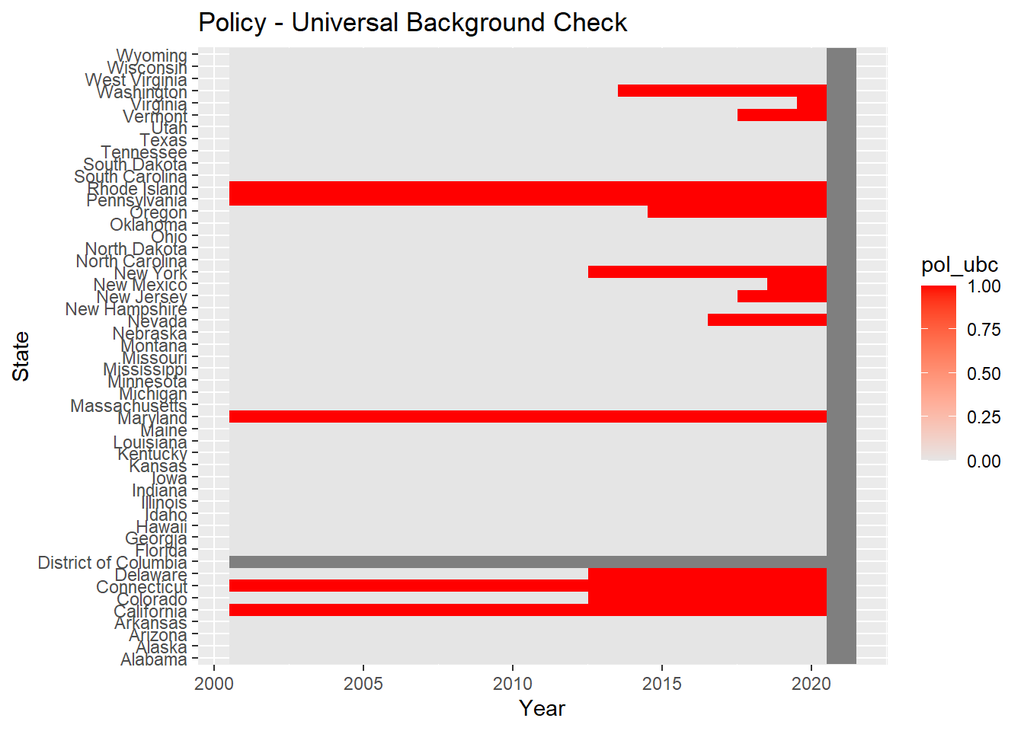

```r
ggplot(data3, aes(x = Year, y = State)) +
  geom_raster(aes(fill=pol_ubc)) +
  scale_fill_gradient(low="grey90", high="red") +
  labs(x="Year", y="State", title="Policy - Universal Background Check")
```

This illustrates that there are three types of state viz `pol_ubc`. For 5 states, e.g. Maryland, this policy was in place throughout the entire sample period. For another 35, e.g. Indiana, the policy was never introduced. For the remaining 10, such as Colorado, a universal background check policy was introduced during the sample period. Without the latter type of states, there would be no difference-in-difference setup.

We could also create the above figure for the `pol_vmisd` variable. If so, you would see that there is no variation in that policy in our sample. Again, this means that there is no difference-in-difference setup using the `pol_vmisd` variable.

We now look at the third policy variable, (c) `pol_mayissue`. From the laws codebook:

```r
print(toString(law_data_codebook[law_data_codebook$Variable.Name == "mayissue","Detailed.Description.of.Provision"]))
```

```
## [1] "Law provides authorities with discretion in deciding whether to grant a concealed carry permit, or the law bans all concealed weapons."
```

Let us look at the development of this policy through time:

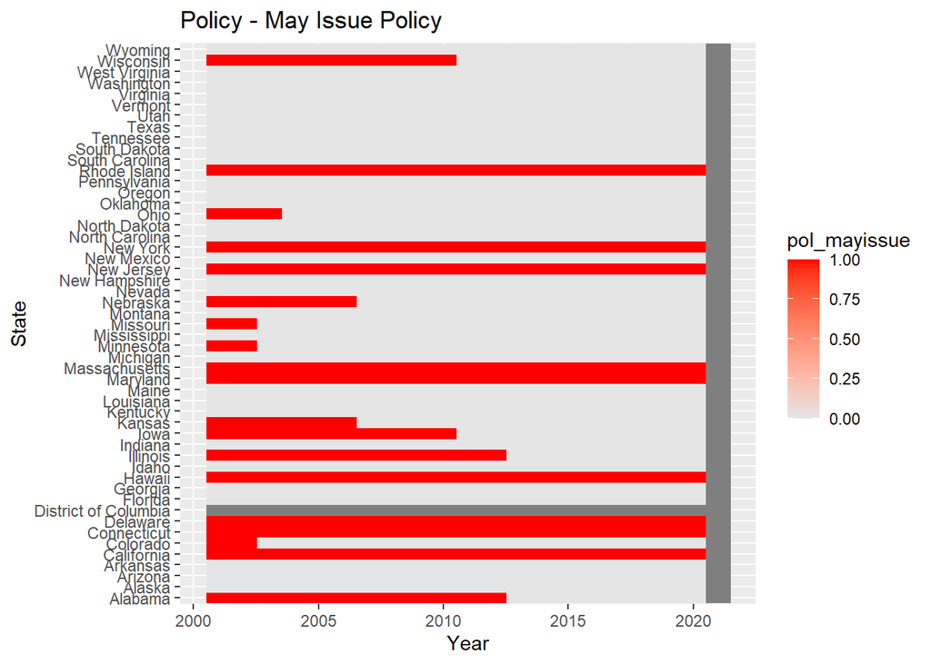

```r
ggplot(data3, aes(x = Year, y = State)) +
  geom_raster(aes(fill=pol_mayissue)) +
  scale_fill_gradient(low="grey90", high="red") +
  labs(x="Year", y="State", title="Policy - May Issue Policy")
```

As you can see, these policies are generally being phased out, meaning that authorities are loosing the ability to deny firearm permits. In terms of a DiD setup we like to evaluate policies that are being introduced, not phased out. Therefore, in the Siegel et al. paper, you will see a reference to a “Shall issue” policy, which is basically the absence of a “May issue” policy. This is defined as one-minus `pol_mayissue`. So let’s add that variable to the data frame.

```r
data3$pol_shallissue <- 1 - data3$pol_mayissue
```

Let us look at the development of this policy through time:

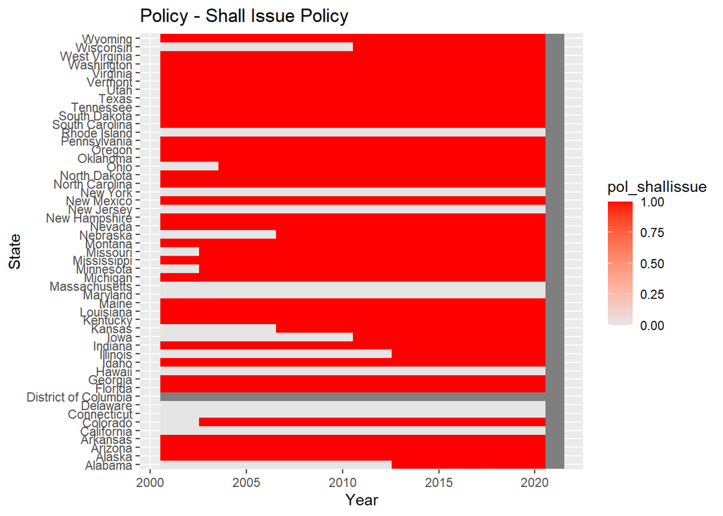

```r
ggplot(data3, aes(x = Year, y = State)) +
  geom_raster(aes(fill=pol_shallissue)) +
  scale_fill_gradient(low="grey90", high="red") +
  labs(x="Year", y="State", title="Policy - Shall Issue Policy")
```

Now you can see that this is a policy being introduced. The policy is really to remove a gun control policy. It is exactly the mirror image of the preceding figure. The variable records whether a gun control policy is being removed. Just like `pol_ubc` this is still a political decision, but in the opposite direction.

The following table illustrates for how many observations (state-years) the policies (a) and (c) are in place. Sometimes such tables are called cross-tabs.

```r
addmargins(table(data3$pol_ubc, data3$pol_shallissue, dnn = c("UBC","Shall Issue")))
```

```
##      Shall Issue
## UBC      0    1  Sum
##   0    146  704  850
##   1     99   51  150
##   Sum  245  755 1000
```

You can discern from this that there are few stat-years (only 51) in which a state had both policies, universal background checks and a shall issue policy, in place. This is perhaps not surprising as the two policies have different emphasis, one tightening access and the other providing easier access.

### Estimation

We will now estimate our first “base” two-way fixed effects (TWFE) model. This is a particular version of a difference-in-difference method.

$$log(fd.pc_{st}) = \alpha_s + \gamma_t +
\tau~ pol_{st} + error_{st}$$

where $log(fd.pc_{st})$ is the log of the age adjusted death rate by firearms and $pol_{st}$ is either `pol_ubc` or `pol_shallissue`. At this stage there are no covariates. $\tau$ is the treatment effect we are seeking to estimate (and hopefully claim that it is causal).

We construct the logged outcome variables and set-up the dataframe as a panel data set.

```r
data3 <- data3 %>% mutate(log.fd.pc = log(firearm.deaths.pc), log.homi.pc = log(homi.pc))
pdata <- pdata.frame(data3, index = c("State","Year")) # defines the panel dimensions
```

We now estimate the model twice, for the variables (a) `pol_ubc` and (c) `pol_shallissue` separately. Recall that we cannot estimate a model for (b) `pol_vmisd` as there is no policy variation in that variable. (You should try and see what happens.) We also estimate state-level cluster robust standard errors.

```r
mod_twfe1 <- lm(log.fd.pc~State+Year+pol_ubc, data = pdata)
se_twfe1 <- sqrt(diag(vcovCL(mod_twfe1, cluster = ~ State)))

mod_twfe2 <- lm(log.fd.pc~State+Year+pol_shallissue, data = pdata)
se_twfe2 <- sqrt(diag(vcovCL(mod_twfe2, cluster = ~ State)))

stargazer(mod_twfe1, mod_twfe2, keep = c("pol_ubc","pol_shallissue"), type="text", se=list(se_twfe1,se_twfe2),
          digits = 6, notes="Cluster (State) Robust standard errors in parenthesis")
```

```
##
## =====================================================================================
##                                                 Dependent variable:
##                                ------------------------------------------------------
##                                                      log.fd.pc
##                                            (1)                        (2)
## -------------------------------------------------------------------------------------
## pol_ubc                                 -0.086122
##                                        (0.054705)
##
## pol_shallissue                                                    0.080584***
##                                                                    (0.019151)
##
## -------------------------------------------------------------------------------------
## Observations                              1,000                      1,000
## R2                                      0.955968                    0.955900
## Adjusted R2                             0.952701                    0.952629
## Residual Std. Error (df = 930)          0.099864                    0.099941
## F Statistic (df = 69; 930)            292.623200***              292.154500***
## =====================================================================================
## Note:                                                     *p<0.1; **p<0.05; ***p<0.01
##                                 Cluster (State) Robust standard errors in parenthesis
```

The result for `pol_shallissue` is very close to that in Siegel et al. (2019), which is 0.082. Recall that the policy is actually the removal of a gun control policy and therefore the positive sign makes sense. Introducing this policy (meaning the removal of a “may issue” policy) makes it easier to acquire a firearm and the results indicate that this has an increasing effect on the outcome variable, here the rate of firearm deaths.

The coefficient for the universal background policy has halved from -0.173 in Siegel et al. to -0.086 here. Whilst this estimate is now statistically insignificant, it is “economically” sizeable. The issue here is the size of the clustered standard error, not the estimate. This happens a lot in DiD analyses.

Why “economically” sizeable? Let us interpret the estimate associated with the `pol_shallissue` variable. The estimated coefficient is 0.081 and is interpreted as follows. If the policy switches from 0 to 1 (here meaning the abolition of a “may issue” policy or the introduction of a “shall issue” policy), then the number of firearm deaths increases by 0.08 log points or 8.4% (the latter using $100*(exp(\hat{\tau})-1)$). What does that mean? The average of the `firearm.deaths.pc` variable is 12 firearm deaths per year per 100,000 population. 8.4% of 12 is 1.01 deaths per 100,000. In Texas, for example, there is a population of about 30 Million. If we project that policy impact onto a population of 30,000,000 (multiply by 300) that would be the equivalent of 302 deaths a year.

A key feature of the TWFE estimator is the inclusion of state and year fixed effects. These are also present in the Siegel et al. paper (see their model on page 2022). Have we really included these by adding “State+Year”? In the dataset `data3`, the `Year` variable is integer-valued, and if we include an integer or numerical variable then R will only estimate one coefficient for that variable.

You can test what happened by looking at how many and which coefficients were estimated:

```r
names(coef(mod_twfe1))
```

```
##  [1] "(Intercept)"         "StateAlaska"         "StateArizona"
##  [4] "StateArkansas"       "StateCalifornia"     "StateColorado"
##  [7] "StateConnecticut"    "StateDelaware"       "StateFlorida"
## [10] "StateGeorgia"        "StateHawaii"         "StateIdaho"
## [13] "StateIllinois"       "StateIndiana"        "StateIowa"
## [16] "StateKansas"         "StateKentucky"       "StateLouisiana"
## [19] "StateMaine"          "StateMaryland"       "StateMassachusetts"
## [22] "StateMichigan"       "StateMinnesota"      "StateMississippi"
## [25] "StateMissouri"       "StateMontana"        "StateNebraska"
## [28] "StateNevada"         "StateNew Hampshire"  "StateNew Jersey"
## [31] "StateNew Mexico"     "StateNew York"       "StateNorth Carolina"
## [34] "StateNorth Dakota"   "StateOhio"           "StateOklahoma"
## [37] "StateOregon"         "StatePennsylvania"   "StateRhode Island"
## [40] "StateSouth Carolina" "StateSouth Dakota"   "StateTennessee"
## [43] "StateTexas"          "StateUtah"           "StateVermont"
## [46] "StateVirginia"       "StateWashington"     "StateWest Virginia"
## [49] "StateWisconsin"      "StateWyoming"        "Year2002"
## [52] "Year2003"            "Year2004"            "Year2005"
## [55] "Year2006"            "Year2007"            "Year2008"
## [58] "Year2009"            "Year2010"            "Year2011"
## [61] "Year2012"            "Year2013"            "Year2014"
## [64] "Year2015"            "Year2016"            "Year2017"
## [67] "Year2018"            "Year2019"            "Year2020"
## [70] "pol_ubc"
```

As you can see the model did include year and state fixed effects. The reason for this is that we used the panel dataset and one of the things that happens when we create a panel dataframe (using `pdata.frame`) is that, if it uses `Year` as the time index it translates that variable into a factor (categorical) variable. It is for this reason that R did actually include year fixed effects. (To make sure you understand this, try seeing what happens if these are not included; that is, try estimating the model by OLS rather than TWFE.)

### Investigating the difference

A different reason why the results may be different is that we cannot be certain about the policy coding used by Siegel et al. (2019). We combined the two policies that had explicitly “universal” in their naming, however, there are more background check policies. In Table 1 of their paper they state which states had the policy implemented in 1991. They are CA, IL, MA, NJ and RI. However, in the above image we see that only CA and RI have the policy implemented in our coding.

You could go back to the policy details and you may find that other policies also imply background checks, such as “universalpermit”. So you could see whether you can replicate Siegel et al. (2019) policy coding. I was unable to replicate this. This merely points to the importance of properly documenting what you do in your work such that someone reading your paper can replicate the work.

Here we will not investigate this line of enquiry any further.

Another reason for differences may be that we are not yet using all the covariates that were included in the Siegel et al. (2019) paper. Once they are included, coefficients may well change. We do not have data for all their covariates, but let’s include the ones we have.

```r
mod_twfe1c <- lm(log.fd.pc~State+Year+pol_ubc+prop18.24+law.officers.pc+ur+vcrime.pc+alcc.pc+incarc.pc+log(Population),
                 data = pdata)
se_twfe1c <- sqrt(diag(vcovCL(mod_twfe1c, cluster = ~ State)))

mod_twfe2c <- lm(log.fd.pc~State+Year+pol_shallissue+prop18.24+law.officers.pc+ur+vcrime.pc+alcc.pc+incarc.pc+log(Population),
                 data = pdata)
se_twfe2c <- sqrt(diag(vcovCL(mod_twfe2c, cluster = ~ State)))

stargazer(mod_twfe1c, mod_twfe2c, keep = c("pol_ubc","pol_shallissue"), type="text",
          se=list(se_twfe1c,se_twfe2c),
          digits = 6, notes="Cluster (State) Robust standard errors in parenthesis")
```

```
##
## =====================================================================================
##                                                 Dependent variable:
##                                ------------------------------------------------------
##                                                      log.fd.pc
##                                            (1)                        (2)
## -------------------------------------------------------------------------------------
## pol_ubc                                 -0.071315
##                                        (0.060671)
##
## pol_shallissue                                                    0.059972***
##                                                                    (0.018651)
##
## -------------------------------------------------------------------------------------
## Observations                               929                        929
## R2                                      0.961502                    0.961353
## Adjusted R2                             0.958166                    0.958004
## Residual Std. Error (df = 854)          0.093416                    0.093596
## F Statistic (df = 74; 854)            288.226700***              287.074700***
## =====================================================================================
## Note:                                                     *p<0.1; **p<0.05; ***p<0.01
##                                 Cluster (State) Robust standard errors in parenthesis
```

You can see that the inclusion of the covariates does not change the main conclusion. In fact, now the coefficient for the `pol_shallissue` variable has also moved away from that published in the paper, although it is still statistically significant.

Recall that we recognised that our data for the outcome variable is not the same as that used in Siegel et al. (2019). Above we used `firearm.deaths.pc` but we also acquired the `homi.pc` data from the F.B.I.. Let us re-run the above models (with covariates) with that outcome variable.

```r
mod_twfe3c <- lm(log.homi.pc~State+Year+pol_ubc+prop18.24+law.officers.pc+ur+vcrime.pc+alcc.pc+incarc.pc+log(Population),
                 data = pdata)
se_twfe3c <- sqrt(diag(vcovCL(mod_twfe3c, cluster = ~ State)))

mod_twfe4c <- lm(log.homi.pc~State+Year+pol_shallissue+prop18.24+law.officers.pc+ur+vcrime.pc+alcc.pc+incarc.pc+log(Population),
                 data = pdata)
se_twfe4c <- sqrt(diag(vcovCL(mod_twfe4c, cluster = ~ State)))

stargazer(mod_twfe3c, mod_twfe4c, keep = c("pol_ubc","pol_shallissue"), type="text",
          se=list(se_twfe3c,se_twfe4c),
          digits = 6, notes="Cluster (State) Robust standard errors in parenthesis")
```

```
##
## =====================================================================================
##                                                 Dependent variable:
##                                ------------------------------------------------------
##                                                     log.homi.pc
##                                            (1)                        (2)
## -------------------------------------------------------------------------------------
## pol_ubc                                 -0.065843
##                                        (0.074830)
##
## pol_shallissue                                                      0.048245
##                                                                    (0.043370)
##
## -------------------------------------------------------------------------------------
## Observations                               929                        929
## R2                                      0.912453                    0.912306
## Adjusted R2                             0.904867                    0.904707
## Residual Std. Error (df = 854)          0.172268                    0.172413
## F Statistic (df = 74; 854)            120.280700***              120.058900***
## =====================================================================================
## Note:                                                     *p<0.1; **p<0.05; ***p<0.01
##                                 Cluster (State) Robust standard errors in parenthesis
```

### A note of caution

In the above, we estimated a TWFE model on a setup with staggered entry, meaning that different states implement a given policy at different calendar times. Much recent methodological research investigates the properties of the TWFE estimator in this setting. It turns out that the properties crucially depend on (a) the parallel trends assumption and (b) on assuming that the policy has the same effect in different states. If either (a) or (b) are not true, the TWFE estimator is biased.

Without going into any details, the following section will show the building blocks needed to deal with situations where this assumption is not met.

## Event studies approach for common entry

One of the issues with the TWFE approach is that we assume that the policy implementation has an immediate and constant impact on the outcome variable. We now relax this assumption and let the data decide about the timing and strength of the policy effect.

This method is really meant for datasets that do have common (and not staggered) entry. Of course staggered policy implementation is a standard feature of many datasets, as is the case here. To create a dataset with common entry, let’s look again at the implementation of the “shall issue” policy through time:

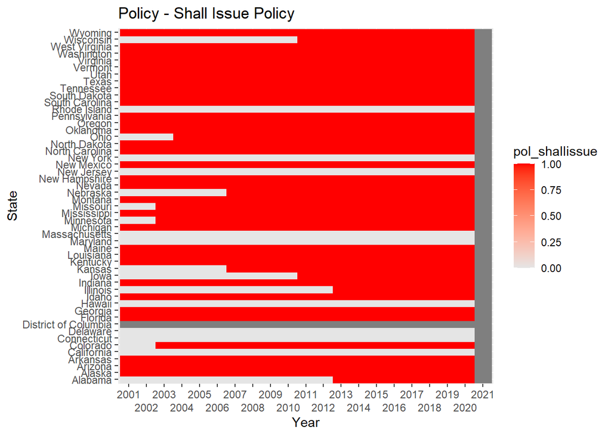

```r
ggplot(pdata, aes(x = Year, y = State)) +
  geom_raster(aes(fill=pol_shallissue)) +
  scale_fill_gradient(low="grey90", high="red") +
  labs(x="Year", y="State", title="Policy - Shall Issue Policy") +
  guides(x = guide_axis(n.dodge = 2)) # this offsets every 2nd x axis label
```

From the full dataset we can create subsets of data that creates a treatment group with common policy entry. For instance pick out the following nine states:

```r
State_sel <- c("Alabama", "Illinois", "Delaware", "Connecticut", "Rhode Island", "New York", "New Jersey", "Massachusetts", "Maryland")
pdata_sub1 <- pdata %>% filter(State %in% State_sel)
```

Now replicate the above plot with this subset.

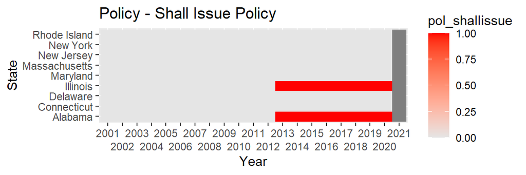

```r
ggplot(pdata_sub1, aes(x = Year, y = State)) +
  geom_raster(aes(fill=pol_shallissue)) +
  scale_fill_gradient(low="grey90", high="red") +
  labs(x="Year", y="State", title="Policy - Shall Issue Policy") +
  guides(x = guide_axis(n.dodge = 2)) # this offsets every 2nd x axis label
```

Here you can see that we are having two states in the treatment group (Illinois and Alabama) who both implement the policy from 2013 onward (common entry) and seven states in the control group (all others). If you have such a “clean” setup, an event study approach is straightforward to implement. We need to create new variables which interact a dummy variable which takes the value 1 for those states that are ever treated (here Illinois and Alabama) with the Year variable.

```r
State_treat <- c("Alabama", "Illinois")
# this creates the ever treated dummy variable
pdata_sub1 <- pdata_sub1 %>% mutate(d = case_when(State %in% State_treat ~ 1,
                                                  TRUE ~ 0))

# below we discuss what d*Year does
mod_event_sub1 <- lm(log.fd.pc~State+d*Year, data = pdata_sub1)
stargazer_HC(mod_event_sub1, type_out="text")
```

```
##
## =========================================================
##                              Dependent variable:
##                     -------------------------------------
##                                   log.fd.pc
## ---------------------------------------------------------
## StateConnecticut                  -1.243***
##                                    (0.087)
##
## StateDelaware                     -0.561***
##                                    (0.089)
##
## StateIllinois                     -0.646***
##                                    (0.015)
##
## StateMaryland                     -0.458***
##                                    (0.086)
##
## StateMassachusetts                -1.683***
##                                    (0.087)
##
## StateNew Jersey                   -1.251***
##                                    (0.089)
##
## StateNew York                     -1.333***
##                                    (0.090)
##
## StateRhode Island                 -1.482***
##                                    (0.090)
##
## d
##
##
## Year2002                           -0.009
##                                    (0.072)
##
## Year2003                           -0.076
##                                    (0.079)
##
## Year2004                           -0.030
```

[output cut: 110 more lines]

[output not shown]

Note that we did not use cluster robust standard errors. Convention is that you should only use them if you have at least 50 clusters (here states), here we only have 9. We therefore use the standard robust standard errors.

Note what variables were included by specifying the model as “log.fd.pc~State+d*Year”:

- a constant (which is included by default)
- State dummy variables, 8 of them, Alabama is the base state here

The remaining variables are included as a result of “d*Year”

- The dummy variable d, the ever treated variable, but note that this is colinear as it is identical to “StateIllinois + StateAlabama”. R realises this and does not report a coefficient, it excludes it from the model
- Year dummy variables, for every year but the base year 2001, they are labeled “Year2002” to “Year2021”
- Interaction terms between d and the Year dummy variables, they are labeled “d:Year2002” to “d:Year2021”.

All of these are automatically included by adding “d*Year” to the regression specification.

It is these last set of coefficients, the interaction terms, that give us the year specific policy effects. Let us display them graphically.

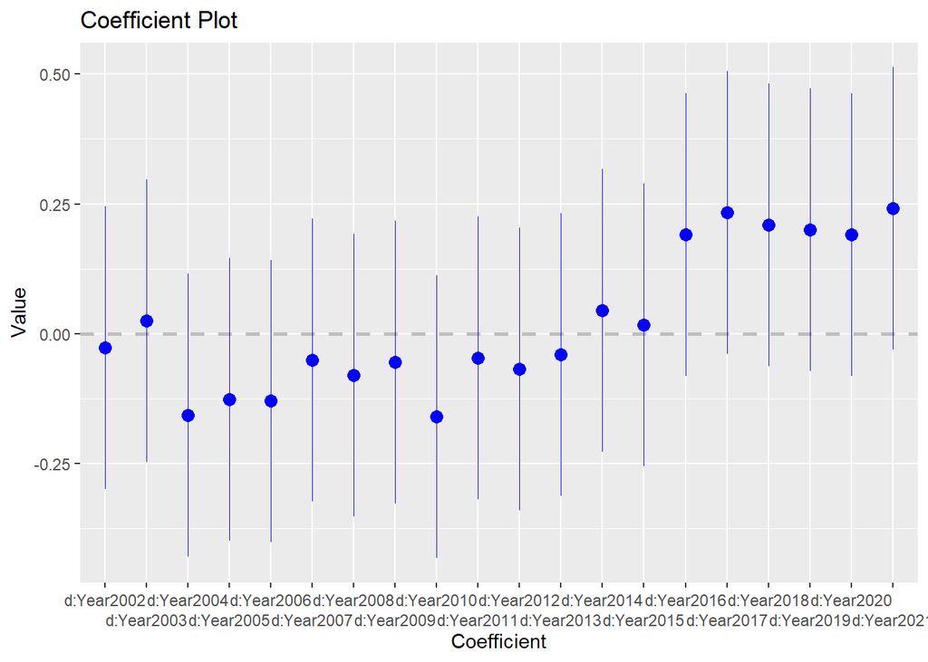

```r
# this line selects all the coefficient names that contain "d:Year"
coef_keep = names(coef(mod_event_sub1))[grepl("d:Year",names(coef(mod_event_sub1)))]

# this creates a coefficient plot
coefplot(mod_event_sub1, coefficients = coef_keep, innerCI = 0, horizontal = TRUE) +
  guides(x = guide_axis(n.dodge = 2)) # this offsets every 2nd x axis label
```

The confidence bars indicate +/- 2 standard errors. However, the standard errors used here are the normal standard errors and not the heteroskedasticity robust ones. Unfortunately the `coefplot` function does not have an option to feed in the correct standard errors. So for now we treat the standard errors as indicative only and we return below to the question of statistical significance.

There are two important observations from this. First, all the coefficients up to the period of policy implementation (2013) are close to 0. This suggests that there is no evidence against the parallel trends assumption prior to the policy implementation. Second, the coefficients after 2015 indicate that in the policy states there was a somewhat positive effect of the policy, although we are not sure about the statistical significance. But note that this result suggests that the effect only manifested itself a few years after the policy introduction (in 2013).

You could re-run the plot without the confidence intervals by adding the option `outerCI = 0`.

We run a hypothesis test to test the hypothesis that all of the post policy coefficients are equal to 0.

```r
coef_test <- c("d:Year2013","d:Year2014","d:Year2015","d:Year2016","d:Year2017","d:Year2018","d:Year2019","d:Year2020","d:Year2021")
lht(mod_event_sub1,coef_test, white.adjust = TRUE)
```

When you do this you will get an error message most likely saying something like “there are aliased coefficients in the model”. The issue here is that the model still includes the variable `d`, the ever treated dummy. R excluded it in the regression output but the `lht` procedure does not do that and the above is R’s charming way of saying that something isn’t right in the model (`lm` brushed this underneath the carpet).

So what we really need to do is to specify the same model as above without the `d`. But that means that we cannot use the neat trick of including `d*Year`. Let’s do a little workaround to get there without having to define all of the more than 40 variables individually.

```r
X <- model.matrix(mod_event_sub1) # puts all the explanatory variables used in mod_event_sub1 into a matrix
X. <- X[, -c(1,10)]  # we delete columns 1 - the intercept - and 10 - the d variable
# this new variable is called "X." unconventional but makes life a little easier below

# now we re-estimate the model using matrix X. which contains all variables
# from the earlier model but for d and the intercept
# the lm function will automatically re-insert the intercept
mod_event_sub1b <- lm(log.fd.pc~X., data = pdata_sub1)
stargazer_HC(mod_event_sub1b, type_out="text")
```

```
##
## ==========================================================
##                               Dependent variable:
##                      -------------------------------------
##                                    log.fd.pc
## ----------------------------------------------------------
## X.StateConnecticut                 -1.243***
##                                     (0.087)
##
## X.StateDelaware                    -0.561***
##                                     (0.089)
##
## X.StateIllinois                    -0.646***
##                                     (0.015)
##
## X.StateMaryland                    -0.458***
##                                     (0.086)
##
## X.StateMassachusetts               -1.683***
##                                     (0.087)
##
## X.StateNew Jersey                  -1.251***
##                                     (0.089)
##
## X.StateNew York                    -1.333***
##                                     (0.090)
##
## X.StateRhode Island                -1.482***
##                                     (0.090)
##
## X.Year2002                          -0.009
##                                     (0.072)
##
## X.Year2003                          -0.076
##                                     (0.079)
##
## X.Year2004                          -0.030
##                                     (0.056)
##
## X.Year2005                          -0.008
```

[output cut: 107 more lines]

```
## X.d:Year2021                        0.241*
##                                     (0.126)
##
## Constant                           2.884***
##                                     (0.071)
##
## ----------------------------------------------------------
## Observations                          189
## R2                                   0.965
## Adjusted R2                          0.953
## Residual Std. Error            0.120 (df = 140)
## F Statistic                80.956*** (df = 48; 140)
## ==========================================================
## Note:                          *p<0.1; **p<0.05; ***p<0.01
##                      Robust standard errors in parenthesis
```

Note that the coefficient estimates are identical to those in `mod_event_sub1`. We basically estimated the same model without R having to silently drop some variables.

Now we can test the null hypothesis that all the coefficients for the interaction terms between `d` and the Years 2013 to 2021 are not different from 0.

```r
# first collect all the variables we want to include into H0 in a list
# Note that now the variables have a "X." at the beginning
coef_test <- c("X.d:Year2013","X.d:Year2014","X.d:Year2015","X.d:Year2016","X.d:Year2017","X.d:Year2018","X.d:Year2019","X.d:Year2020","X.d:Year2021")

# Now we feed this into the lht function to test
# we also feed in the heteroskedasticity robust standard errors
lht(mod_event_sub1b,coef_test,  vcov = vcovHC(mod_event_sub1b, type = "HC1"))
```

```
##
## Linear hypothesis test:
## X.d:Year2013 = 0
## X.d:Year2014 = 0
## X.d:Year2015 = 0
## X.d:Year2016 = 0
## X.d:Year2017 = 0
## X.d:Year2018 = 0
## X.d:Year2019 = 0
## X.d:Year2020 = 0
## X.d:Year2021 = 0
##
## Model 1: restricted model
## Model 2: log.fd.pc ~ X.
##
## Note: Coefficient covariance matrix supplied.
##
##   Res.Df Df      F   Pr(>F)
## 1    149
## 2    140  9 2.9569 0.003016 **
## ---
## Signif. codes:  0 '***' 0.001 '**' 0.01 '*' 0.05 '.' 0.1 ' ' 1
```

The result suggests (p-value of 0.003) that there does seem to be a positive effect after the policy introduction.

Note that the `lht` function allows you to feed in the standard error procedure you need to use. Here, as we only had few states we fed in the procedure to estimate heteroskedasticity robust standard errors. What you see here is exactly what `stargazer_HC` does underneath the hood. If you were using cluster robust standard errors you would use `vcov = vcovCL(mod_event_sub1b, cluster = ~ State)` instead.

Another advantage of estimating the event study model is to be able to present some evidence which will allow you to make informed statements about the parallel trends assumption. If the parallel trends assumption holds you would expect all coefficients to `d:YearXXXX` interaction terms before the policy intervention to be 0. So we can test this hypothesis in the same manner as above, just by collecting a different list of coefficient names.

```r
# first collect all the variables we want to include into H0 in a list
# Note that now the variables have a "X." at the beginning
coef_test <- c("X.d:Year2002","X.d:Year2003","X.d:Year2004","X.d:Year2005","X.d:Year2006","X.d:Year2007",
               "X.d:Year2008","X.d:Year2009", "X.d:Year2010","X.d:Year2011","X.d:Year2012")

# Now we feed this into the lht function to test
# we also feed in the heteroskedasticity robust standard errors
lht(mod_event_sub1b,coef_test,  vcov = vcovHC(mod_event_sub1b, type = "HC1"))
```

```
##
## Linear hypothesis test:
## X.d:Year2002 = 0
## X.d:Year2003 = 0
## X.d:Year2004 = 0
## X.d:Year2005 = 0
## X.d:Year2006 = 0
## X.d:Year2007 = 0
## X.d:Year2008 = 0
## X.d:Year2009 = 0
## X.d:Year2010 = 0
## X.d:Year2011 = 0
## X.d:Year2012 = 0
##
## Model 1: restricted model
## Model 2: log.fd.pc ~ X.
##
## Note: Coefficient covariance matrix supplied.
##
##   Res.Df Df      F Pr(>F)
## 1    151
## 2    140 11 1.2017 0.2913
```

Now you see that the null hypothesis of all these coefficients being equal to 0 is not rejected. This means that there is, in these data, no evidence against the parallel trends assumption before the policy was implemented. Note that this is not the same as testing the parallel trends assumption (which we cannot formally do). That refers to the assumption that after the policy was introduced both treatment and control group states would have evolved parallel. This result is merely suggestive as it used only coefficients from before the policy was introduced.

## Outlook

For the event studies approach we set up a clean treatment group in the sense that all states in the treatment group have implemented the policy in the same period (common entry). This then enabled us to estimate the time profile of the policy effect (here we found that the effect is delayed) and also obtain some good evidence regarding the parallel trends assumption.

When we looked at the TWFE model we had a somewhat more flexible setup. In particular we allowed treatments to come in at different time-periods (staggered policy design). Very recent research into the properties of these estimation methods has concluded that estimating TWFE models with staggered policy design can be very problematic and deliver misleading results, in particular if the effects of the policy on outcome variables differs between states. Imagine that the introduction of a shall policy in Illinois had a different effect on firearm deaths than the introduction of the same policy in Alabama. This is a situation which is not unlikely in most examples.

Very recent methodological advances are dealing with such situations. They are not covered here. However, a simple way around this issue is to divide your sample into clean setups like the one above which only had Illinois and Alabama in the treatment group as they introduced the policy at the same time. If you go back to the earlier image that displays when states introduced policies you will find that you could construct another clean treatment group with Nebraska and Kansas. As it turns out, most of the recent advances in Difference-in-Difference estimation make clever use of such clean treatment groups.